# Ejercicio 3 - Estadistica Computacional

Cristóbal Marchant

2022-03-23

# Problema 1

### A) Señale el tipo de variable aleatoria y la distribución que sigue.

Posee una variable aleatoria discreta, con distribución binominal

### B) Determine la función de probabilidad de masa.

```r
# n = Total de los elemententos seleccionados (3)
# x = Toma el valor de 0, 1, 2 o 3
# P = Probabilidad de exito (0.8)

funcionMasa= function(n, x, P){
  (factorial(n)/(factorial(x) * (factorial(n - x)))) * (P**x) * (1-P)**(n-x)
}
funcionMasa(3, 0, 0.8) + funcionMasa(3, 1, 0.8) + funcionMasa(3, 2, 0.8) + funcionMasa(3, 3, 0.8)
```

```
## [1] 1
```

### C) Grafique la distribución.

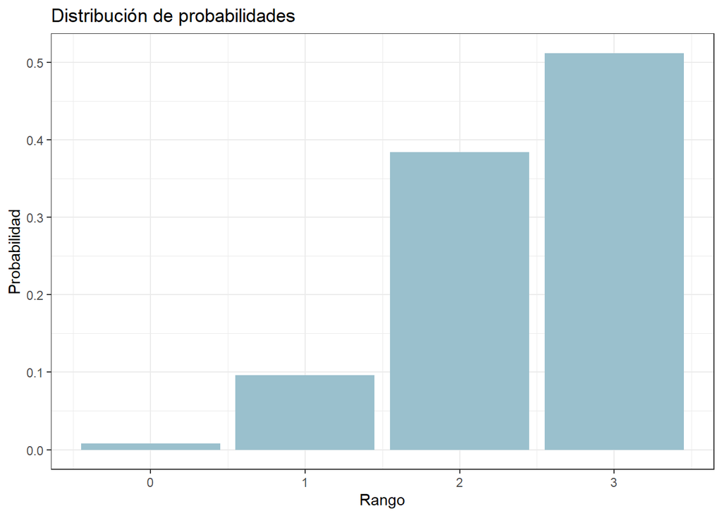

```r
# Datos
rango = seq(0,3)
distribucion = dbinom(rango, size = 3,prob = 0.8)
datos=data.frame(rango,distribucion)

# Gafico
library("ggplot2")
grafico = ggplot(data=datos,aes(x=rango,y=distribucion))
grafico = grafico + geom_bar(stat="identity",fill="lightblue3")
grafico = grafico + theme_bw() + ggtitle("Distribución de probabilidades")
grafico = grafico + xlab("Rango") + ylab("Probabilidad")
plot(grafico)
```

# Problema 2

### A) Señale el tipo de variable aleatoria y la distribución que sigue.

Tomando en cuenta el problema y lo que nos piden, tendriamos una Variable aleatoria discreta con distribución binomial negativa

### B) ¿Cuál es la probabilidad de que cuatro o más evaluaciones deban ser efectuadas para detectar a dos personas portadoras del gen?

```r
#p (x >= 4) = 1 - (P(x=3) + P(x=2))
1 - (dnbinom(3-2, size=2, prob=0.1) + dnbinom(x=2-2, size=2, prob=0.1))
```

```
## [1] 0.972
```

### C) ¿Cuál es el número esperado de evaluaciones que debo realizar para detectar dos personas portadoras del gen?

```r
# E(x)= size/prob
2/0.1
```

```
## [1] 20
```

### D) Grafique la distribución.

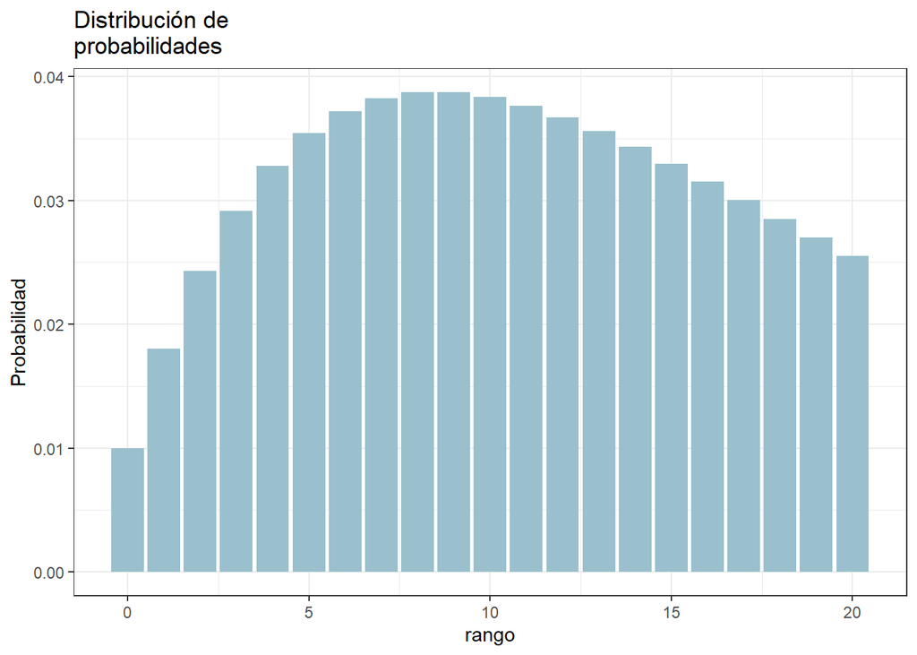

```r
#Datos
rango = seq(0,20)
intentos_fallidos=2
distribucion = dnbinom(x=rango, size=intentos_fallidos, prob=0.1)
datos=data.frame(rango,distribucion)

#Grafico
library("ggplot2")
grafico = ggplot(data=datos,aes(x=rango,y=distribucion))
grafico = grafico + geom_bar(stat="identity",fill="lightblue3")
grafico = grafico + theme_bw() + ggtitle("Distribución de
probabilidades")
grafico = grafico + xlab("rango") + ylab("Probabilidad")
plot(grafico)
```

# Problema 3

### A) Señale el tipo de variable aleatoria y la distribución que sigue.

Analizando el enunciado y los ejercicios este presenta una variable aletaria discreta con distibución hipergeométrica

### B) Si a 10 hombres de la empresa se les hace la prueba del marcador en este cromosoma, ¿cuál es la probabilidad de que exactamente 1 hombre tenga el marcador?

```r
# (x=1)
# dhyper(x, m, n, k)
dhyper(1, 800*0.3, 800 - (800*0.3), 10)
```

```
## [1] 0.1200794
```

### C) Si a 10 hombres de la empresa se les hace la prueba del marcador en este cromosoma, ¿cuál es la probabilidad de que más de 1 tenga el marcador?

```r
# (x>1)
1 - (dhyper(1, 800*0.3, 800 - (800*0.3), 10)) - (dhyper(0, 800*0.3, 800 - (800*0.3), 10))
```

```
## [1] 0.8523523
```

### D) Grafique la distribución

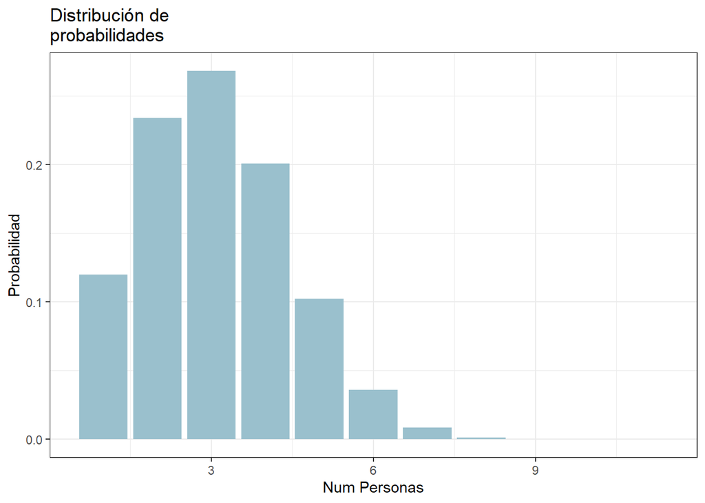

```r
exitos=seq(0:10)
distribucion = dhyper(x=exitos, 800*0.3, 800 - (800*0.3), 10)
datos=data.frame(exitos,distribucion)

library("ggplot2")
grafico = ggplot(data=datos,aes(x=exitos,y=distribucion))
grafico = grafico + geom_bar(stat="identity",fill="lightblue3")
grafico = grafico + theme_bw() + ggtitle("Distribución de
probabilidades")
grafico = grafico + xlab("Num Personas") + ylab("Probabilidad")
plot(grafico)
```

# Problema 4

### A) Señale el tipo de variable aleatoria y la distribución que sigue.

Variable aleatoria discreta con distribucion de possion

### B) ¿Cuál es la probabilidad de que haya exactamente cinco llamadas en una hora?

```r
k = 5       #numero de llamadas en 1 hora
lambda = 8  #promdio de llamadas por hora
dpois(k,lambda)
```

```
## [1] 0.09160366
```

### C) ¿Cuál es la probabilidad de que haya tres llamadas o menos en una hora?

```r
(dpois(0,8)) + (dpois(1,8)) + (dpois(2,8)) + (dpois(3,8))
```

```
## [1] 0.04238011
```

# Problema 5

### A) ¿cuáles son la media y la varianza del tiempo total para completar estas cirugías?

Se tiene a la media = 129 * 10 y la varianza = (14^2) * 10

```r
media = 129*10
varianza = (14**2)*10
c(media, varianza)
```

```
## [1] 1290 1960
```

# Problema 6

### Problema 1

```r
### z = (x - media)/desviacion
z = ((3 + 0.5) -(3*0.8))/(sqrt(3*0.8*(1-0.8)))
pnorm(z)
```

```
## [1] 0.9438244
```

Se muestra que (n * p) -> (3 * 0.8) y (n * (1 - p)) -> (3 * (1-0.8)) son menores a 5, por lo que la aproximación no es buena.

### Problema 4

```r
# 1
#lambda = 8
z = (5-8)/sqrt(8)
pnorm(z)
```

```
## [1] 0.1444222
```

```r
# 2
(pnorm((0-8)/sqrt(8))) + (pnorm((1-8)/sqrt(8))) + (pnorm((2-8)/sqrt(8))) + (pnorm((3-8)/sqrt(8)))
```

```
## [1] 0.06450039
```